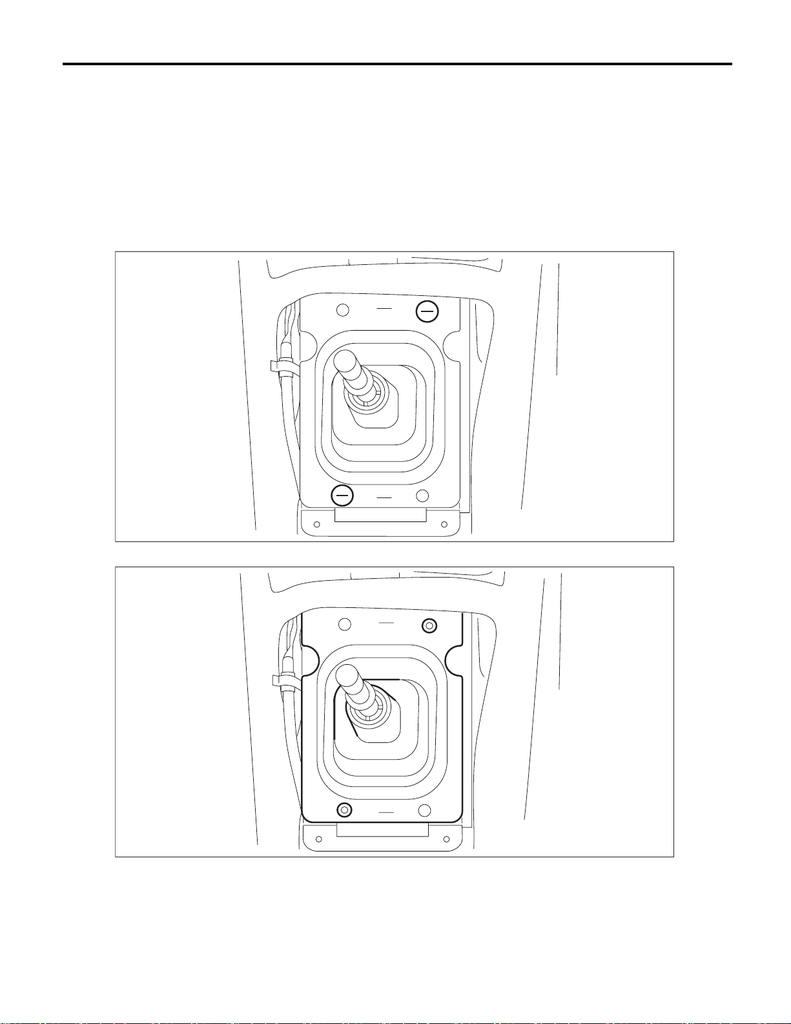

CS-54

MT Gear Shift Lever

CONTROL SYSTEMS

7. MT Gear Shift Lever

A: REMOVAL

1. STI MODEL

1) Disconnect the ground cable from battery.

2) Remove the gear shift knob by turning it counterclockwise.

3) Remove the console box assembly. <Ref. to EI-67, REMOVAL, Console Box.>

4) Remove the cover - shift lever. <Ref. to EI-67, REMOVAL, Console Box.>

5) Remove the panel center LWR LH and RH. <Ref. to EI-67, REMOVAL, Console Box.>

6) Remove the clamp.

7) Remove the boot and insulator assembly.

CS-01784

CS-01785

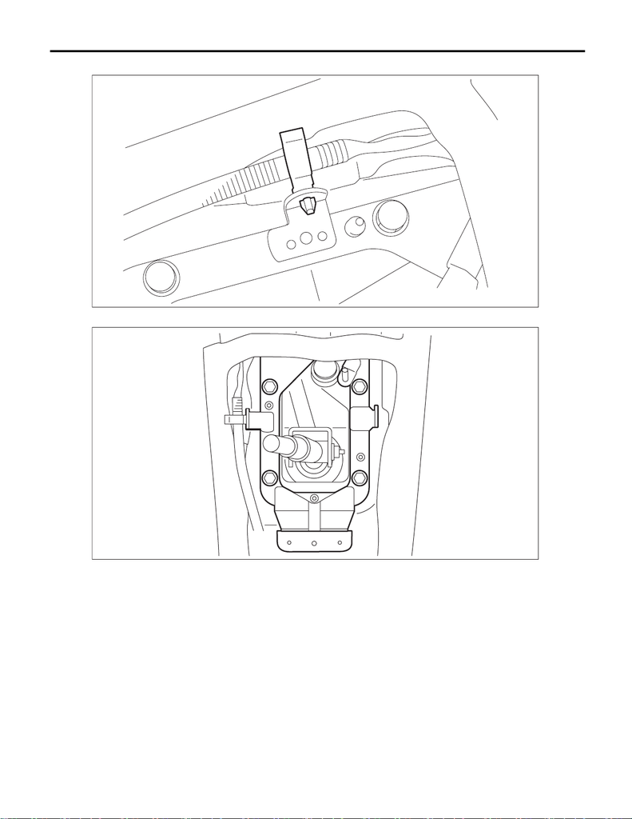

CS-55

MT Gear Shift Lever

CONTROL SYSTEMS

8) Remove the harness clamp.

9) Remove the plate COMPL.

10) Lift up the vehicle.

11) Remove the center exhaust pipe (rear). <Ref. to EX(STI)-7, REMOVAL, Center Exhaust Pipe.>

CS-01786

CS-01787

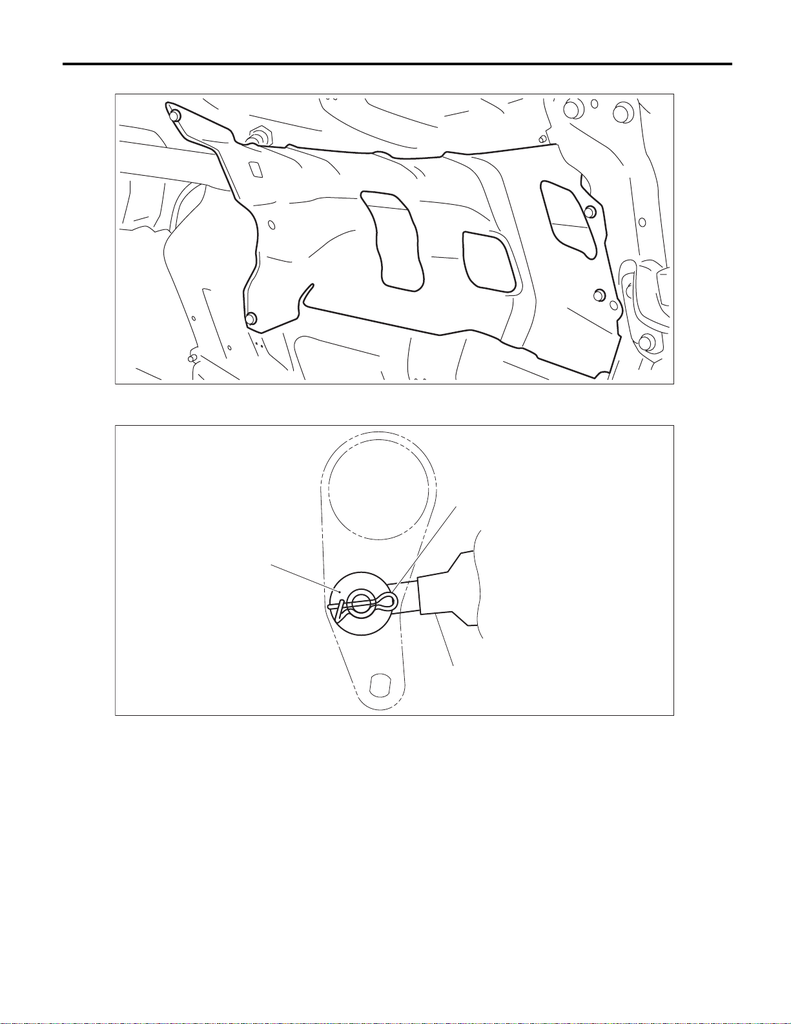

CS-56

MT Gear Shift Lever

CONTROL SYSTEMS

12) Remove the center exhaust cover.

13) Remove the crossmember. <Ref. to 6MT(TY85)-29, REMOVAL, Transmission Mounting System.>

14) Remove the snap pin and washer, and remove the reverse check cable.

(A) Snap pin (B) Washer (C) Reverse check cable

CS-01630

CS-01788

(B)

(A)

(C)

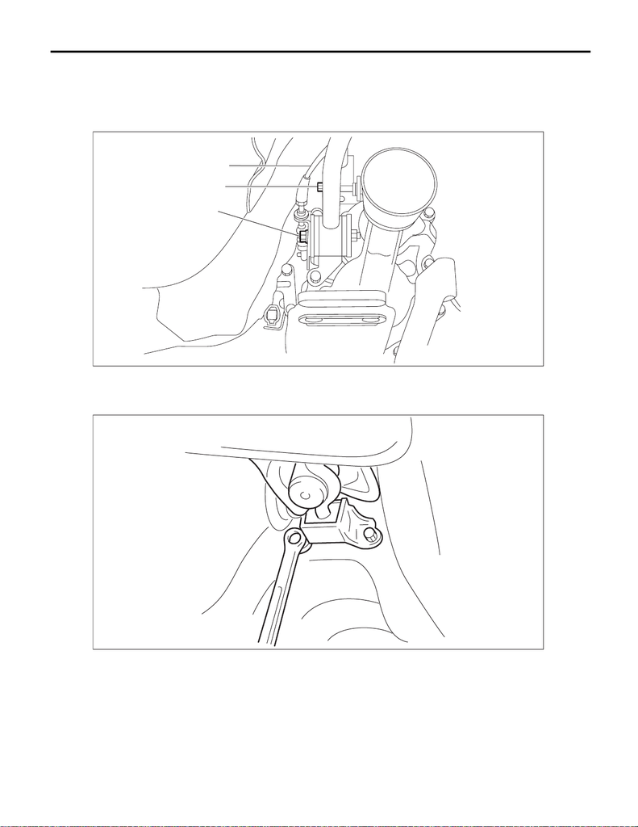

CS-57

MT Gear Shift Lever

CONTROL SYSTEMS

NOTE:

16) Remove the cushion rubber.

17) Remove the gear shift lever.

(A) Joint COMPL bolt (B) Stay bolt (C) Reverse check cable

CS-01789

(C)

(A)

(B)

CS-01790

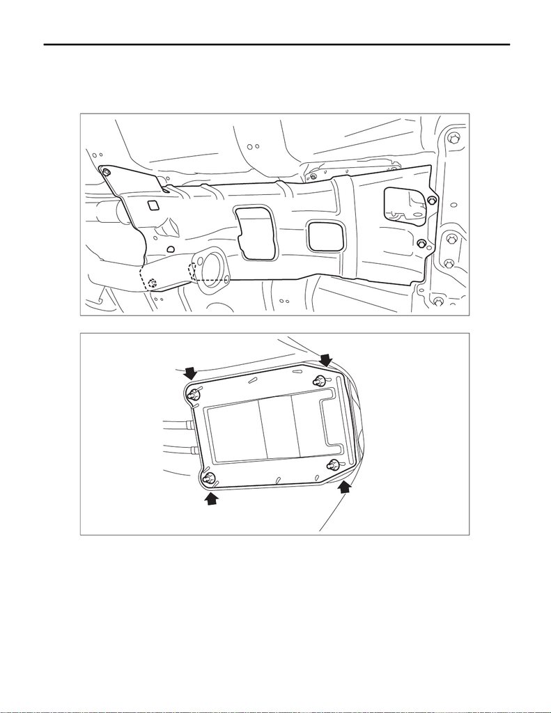

CS-58

MT Gear Shift Lever

CONTROL SYSTEMS

2. EXCEPT FOR STI MODEL

1) Disconnect the ground terminal from battery sensor. <Ref. to NT-5, BATTERY, NOTE, Note.>

2) Lift up the vehicle.

3) Remove the center exhaust pipe (rear). <Ref. to EX(w/o STI)-35, REMOVAL, Center Exhaust Pipe.>

4) Remove the center exhaust cover.

5) Remove the cable cover plate.

CS-01671

CS-01848

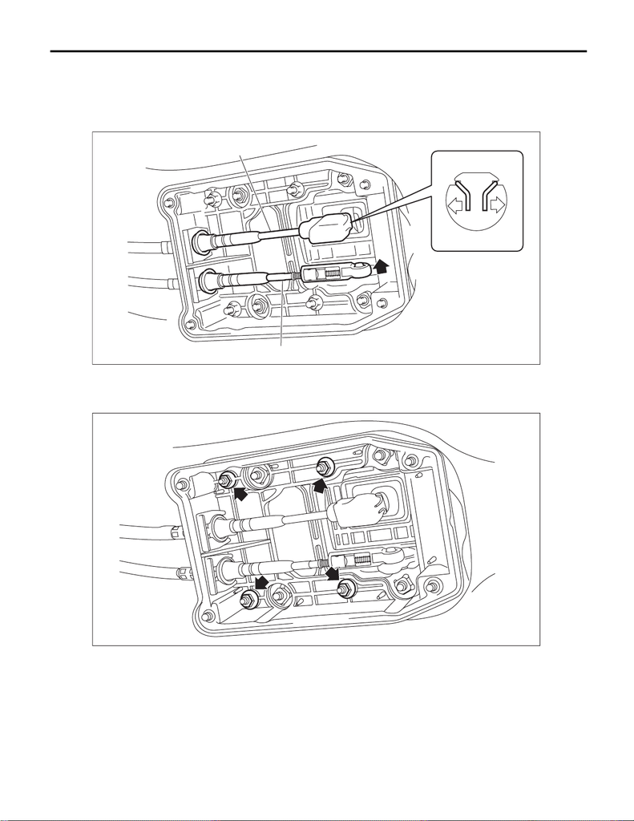

CS-59

MT Gear Shift Lever

CONTROL SYSTEMS

6) Disconnect the MT gear shift cable and MT gear select cable.

CAUTION:

Be careful not to deform the cable inner.

(1) Pull out down the MT gear shift cable to spread the spring.

(2) Push the MT gear select cable in the direction of arrow, and remove it.

7) Remove the cable cover assembly.

(A) MT gear shift cable (B) MT gear select cable

CS-01520

(A)

(B)

CS-01144

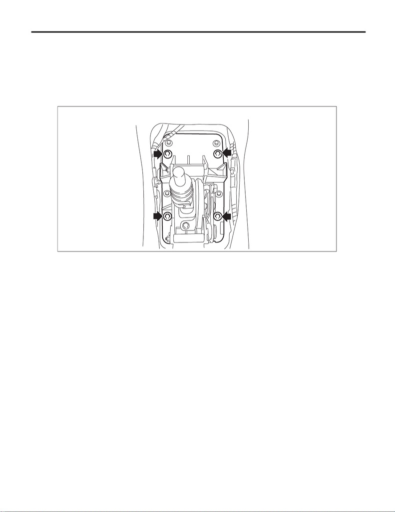

CS-60

MT Gear Shift Lever

CONTROL SYSTEMS

8) Lower the vehicle.

9) Remove the console box assembly. <Ref. to EI-67, REMOVAL, Console Box.>

10) Remove the gear shift knob and remove the cover - shift lever. <Ref. to EI-67, REMOVAL, Console Box.>

11) Remove the panel center LWR LH and RH. <Ref. to EI-67, REMOVAL, Console Box.>

12) Remove the harness clamp.

13) Remove the gear shift lever assembly.

NOTE:

The MT gear shift lever cannot be disassembled.

CS-01672

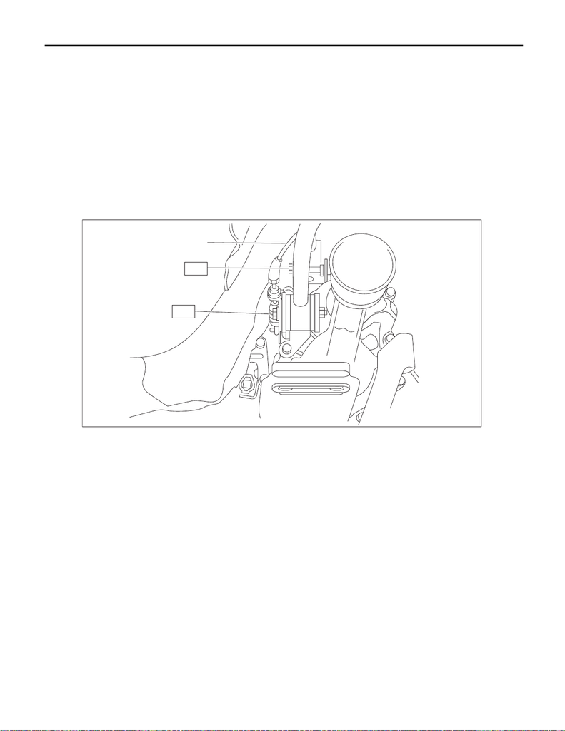

CS-61

MT Gear Shift Lever

CONTROL SYSTEMS

B: INSTALLATION

1. STI MODEL

1) Insert the gear shift lever from the bottom of the vehicle.

NOTE:

After inserting the rod and stay, temporarily put them onto transmission mount.

2) Install the cushion rubber.

Tightening torque:

18 N·m (1.8 kgf-m, 13.3 ft-lb)

3) Move the transmission to the right side of the vehicle, and install the joint COMPL and stay.

Tightening torque:

T1: 12 N·m (1.2 kgf-m, 8.9 ft-lb)

T2: 32 N·m (3.3 kgf-m, 23.6 ft-lb)

(A) Reverse check cable

CS-01791

(A)

T1

T2

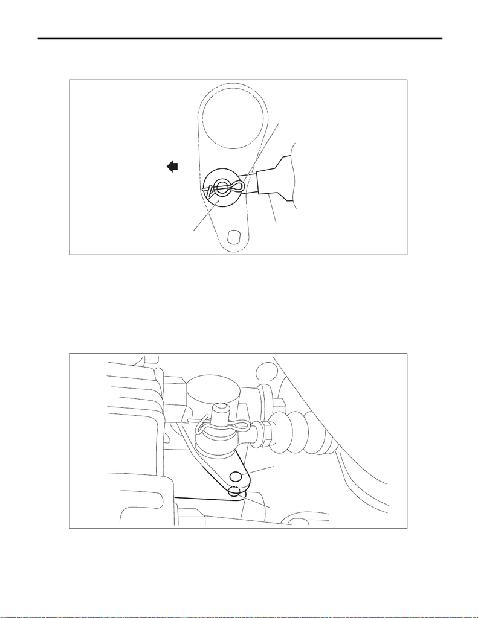

CS-62

MT Gear Shift Lever

CONTROL SYSTEMS

4) Install the reverse check cable, washer and snap pin.

NOTE:

Pay attention to the installing direction of the snap ring.

5) Make sure the hole of extension case is aligned with that of reverse check lever. If the hole positions are

not aligned, adjust the reverse check cable. <Ref. to CS-120, ADJUSTMENT, Reverse Check Cable.>

NOTE:

• Check that the M3 bolt goes through the hole of reverse check lever and can be inserted into the hole of

extension case.

• When checking visually, confirm that the gap of hole positions is 0.5 mm (0.02 in) or less.

(A) Reverse check cable (C) Snap pin (D) Front side

(B) Washer

(A) Hole of reverse check lever (B) Hole of extension case

CS-01792

(B)

(D)

(C)

(A)

CS-01793

(A)

(B)

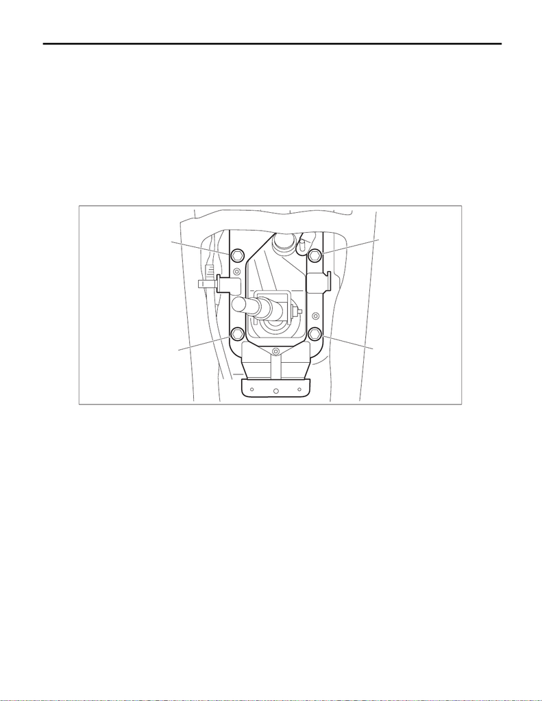

CS-63

MT Gear Shift Lever

CONTROL SYSTEMS

6) Install the crossmember. <Ref. to 6MT(TY85)-29, INSTALLATION, Transmission Mounting System.>

7) Install the center exhaust cover.

8) Install the center exhaust pipe (rear). <Ref. to EX(STI)-8, INSTALLATION, Center Exhaust Pipe.>

9) Install the plate COMPL.

NOTE:

Be careful not to twist the inner boot when installing.

Tightening torque:

18 N·m (1.8 kgf-m, 13.3 ft-lb)

(1) Set the plate COMPL to the vehicle.

(2) Temporarily tighten the bolt (A).

(3) Tighten the bolt (B).

(4) Tighten the bolt (A).

(5) Tighten the bolts (C) and (D).

10) Install the harness clamp to the plate COMPL.

11) Install the boot and insulator assembly, and secure with a clamp.

12) Install the panel center LWR LH and RH. <Ref. to EI-68, INSTALLATION, Console Box.>

13) Install the cover - shift lever. <Ref. to EI-68, INSTALLATION, Console Box.>

14) Install the console box assembly. <Ref. to EI-68, INSTALLATION, Console Box.>

15) Install the gear shift knob by turning it clockwise.

CAUTION:

Do not turn the gear shift knob excessively to prevent it from being damaged.

16) Make sure the gears can be shifted accurately into each gear.

17) Connect the battery ground terminal.

CS-01794

(B)

(A)

(C)

(D)

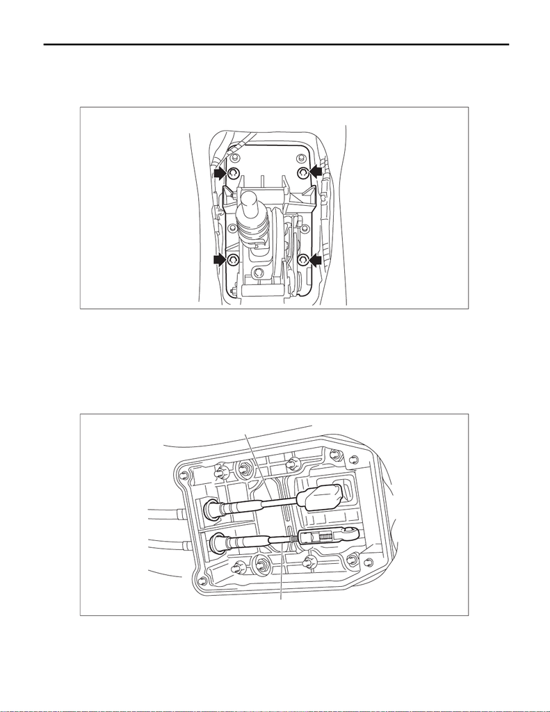

CS-64

MT Gear Shift Lever

CONTROL SYSTEMS

2. EXCEPT FOR STI MODEL

1) Install the gear shift lever assembly.

Tightening torque:

18 N·m (1.8 kgf-m, 13.3 ft-lb)

2) Install the harness clamp.

3) Lift up the vehicle.

4) Install the cable cover assembly.

Tightening torque:

7.5 N·m (0.8 kgf-m, 5.5 ft-lb)

5) Connect the MT gear shift cable and MT gear select cable.

CAUTION:

Be careful not to deform the cable inner.

(A) MT gear shift cable (B) MT gear select cable

CS-01672

CS-01146

(A)

(B)

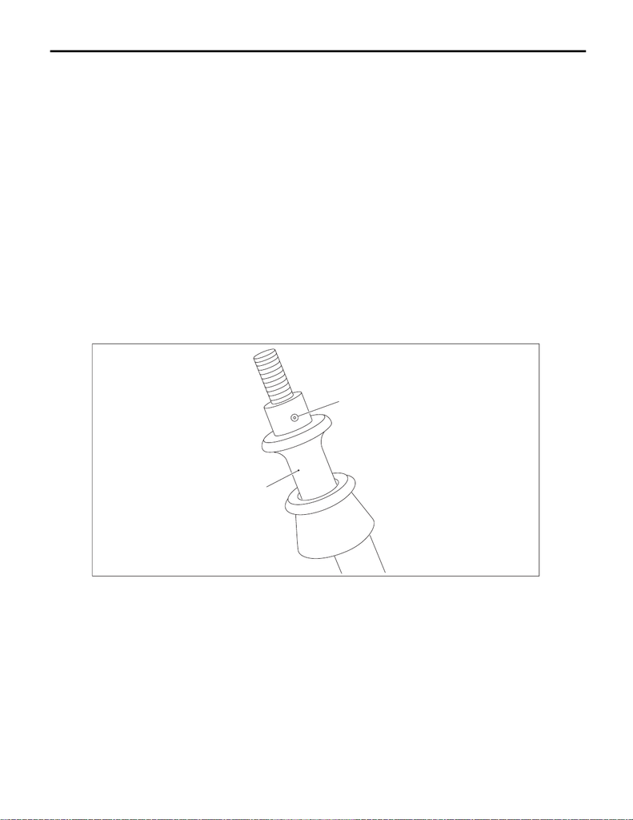

CS-65

MT Gear Shift Lever

CONTROL SYSTEMS

6) Attach the cable cover plate.

Tightening torque:

7.5 N·m (0.8 kgf-m, 5.5 ft-lb)

7) Install the center exhaust cover.

Tightening torque:

18 N·m (1.8 kgf-m, 13.3 ft-lb)

8) Install the center exhaust pipe (rear). <Ref. to EX(w/o STI)-41, INSTALLATION, Center Exhaust Pipe.>

9) Lower the vehicle.

10) Adjust the detent of the MT gear shift lever. <Ref. to CS-82, ADJUSTMENT, MT Gear Shift Lever.>

11) Install the panel center LWR LH and RH. <Ref. to EI-68, INSTALLATION, Console Box.>

12) Install the cover - shift lever, and install the gear shift knob. <Ref. to EI-68, INSTALLATION, Console

Box.>

13) Install the console box assembly. <Ref. to EI-68, INSTALLATION, Console Box.>

14) Make sure the gears can be shifted accurately into each gear. Adjust the MT gear select lever, if the

gears cannot be shifted correctly. <Ref. to CS-105, ADJUSTMENT, MT Gear Select Cable.>

15) Connect the ground terminal to battery sensor. <Ref. to NT-5, BATTERY, NOTE, Note.>

C: DISASSEMBLY

NOTE:

Disassemble procedures are only for STI model.

1) Remove the spring pin from the slider.

(A) Slider (B) Spring pin

CS-01795

(A)

(B)

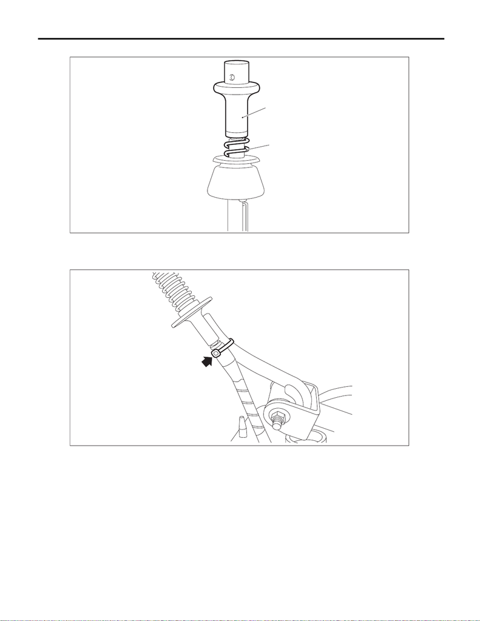

CS-66

MT Gear Shift Lever

CONTROL SYSTEMS

2) Remove the slider and spring.

3) Cut off the band clip.

(A) Slider (B) Spring

CS-01796

(A)

(B)

CS-01797

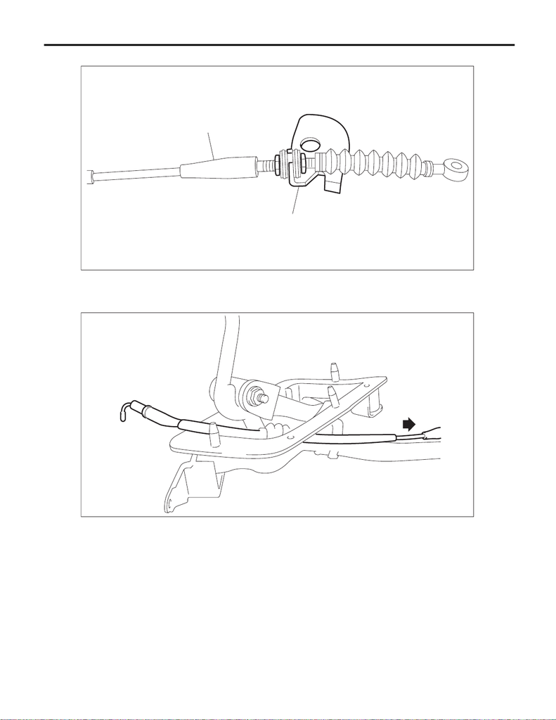

CS-67

MT Gear Shift Lever

CONTROL SYSTEMS

4) Remove the reverse check cable from the cable plate.

5) Remove the reverse check cable.

(A) Cable plate (B) Reverse check cable

CS-01798

(A)

(B)

CS-01799

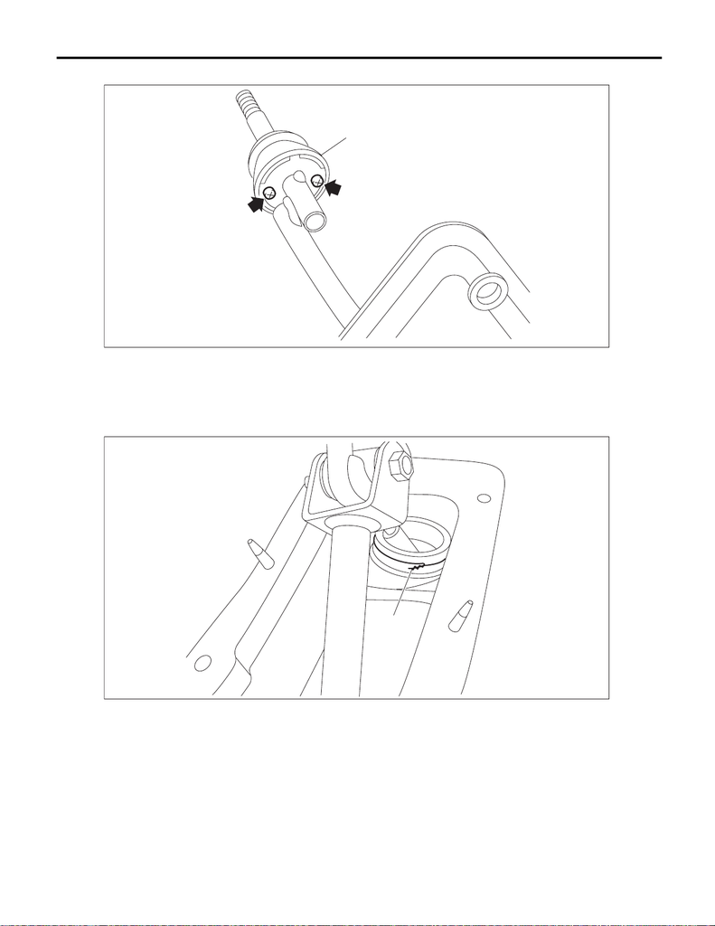

CS-68

MT Gear Shift Lever

CONTROL SYSTEMS

6) Remove the holder and spring.

7) Disassemble the lock wire.

NOTE:

Do not reuse the lock wire.

(A) Holder

(A) Lock wire

CS-01800

(A)

CS-01801

(A)

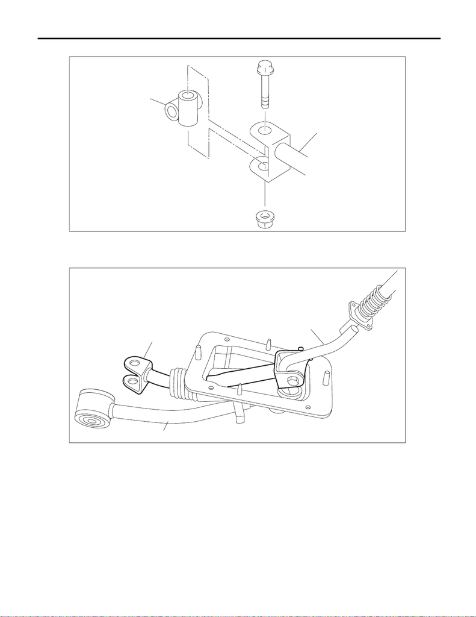

CS-69

MT Gear Shift Lever

CONTROL SYSTEMS

8) Remove the boss from the rod.

9) Remove the rod from lever.

(A) Rod (B) Boss

(A) Rod (B) Lever (C) Stay

CS-01802

(B)

(A)

CS-01803

(C)

(A)

(B)

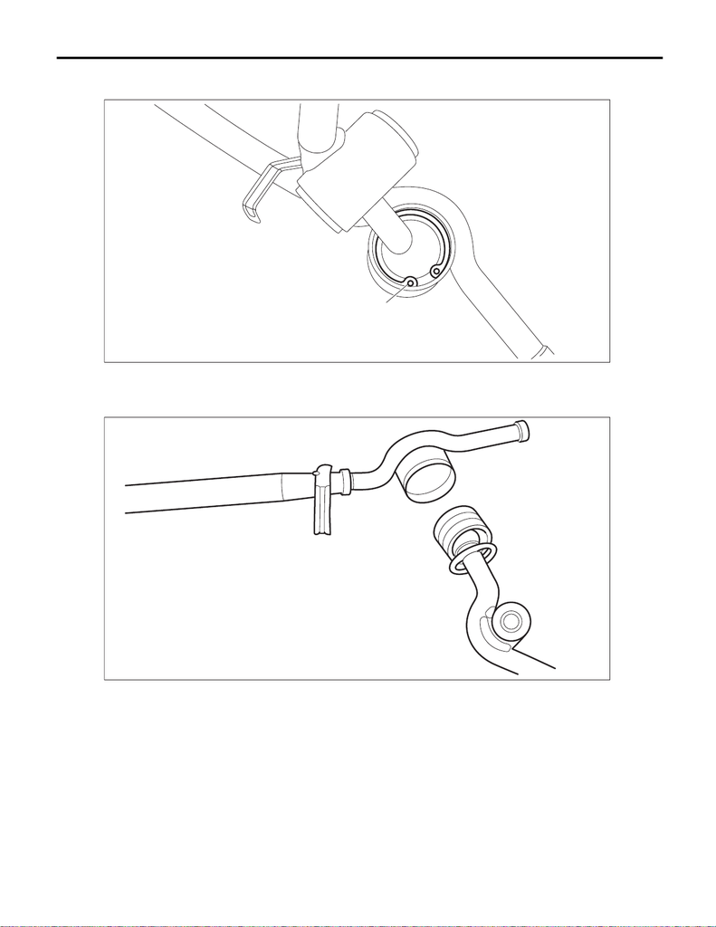

CS-70

MT Gear Shift Lever

CONTROL SYSTEMS

10) Separate the rod and inner boot.

11) Remove the snap ring.

12) Separate the gear shift lever and the stay.

(A) Snap ring

CS-01804

(A)

CS-01805

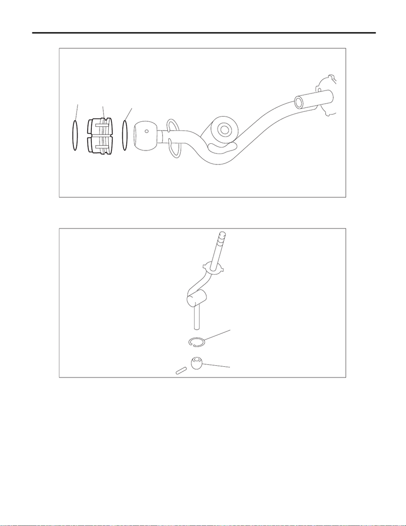

CS-71

MT Gear Shift Lever

CONTROL SYSTEMS

13) Remove the O-ring and bushing.

14) Remove the spring pin, and then remove the bushing and snap ring.

(A) O-ring (B) Bushing

(A) Bushing (B) Snap ring

CS-01806

(A)

(B)

(A)

CS-01807

(A)

(B)

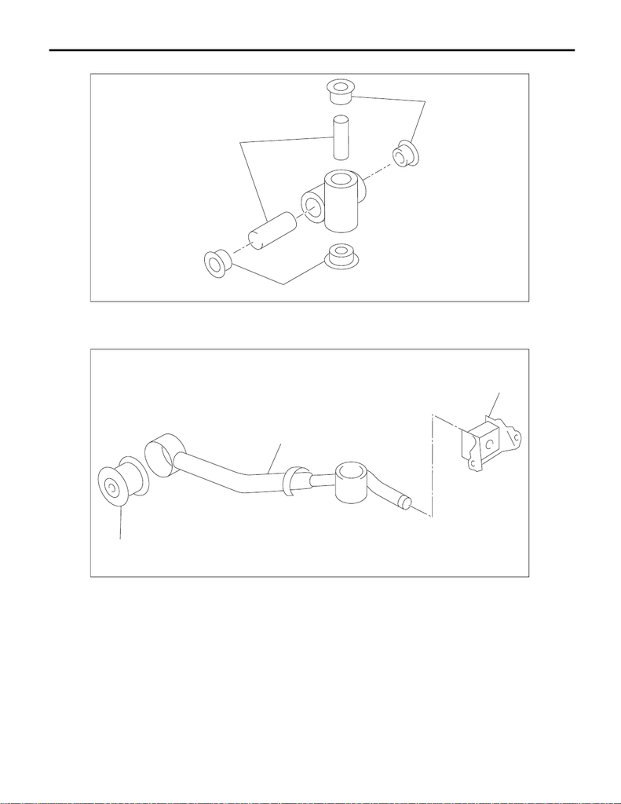

CS-72

MT Gear Shift Lever

CONTROL SYSTEMS

15) Remove the bushing and spacer from the boss.

16) Remove the bushing and cushion rubber from the stay.

(A) Bushing (B) Spacer

(A) Bushing (B) Stay (C) Cushion rubber

CS-01808

(B)

(A)

(A)

CS-01809

(B)

(C)

(A)

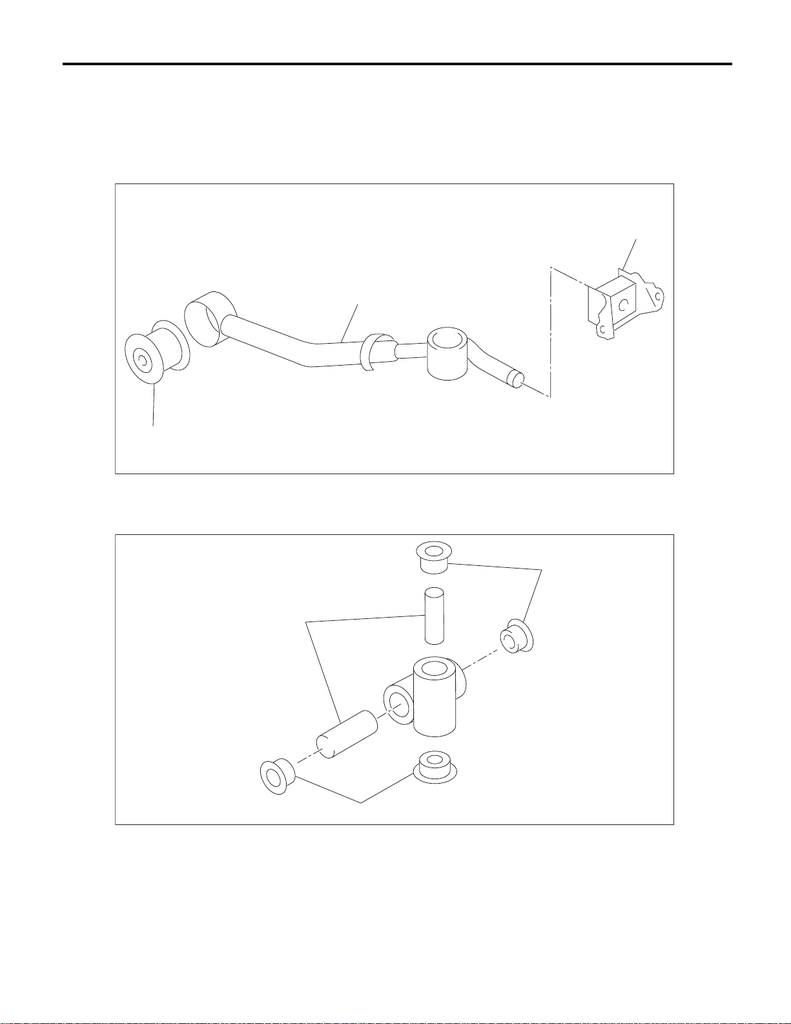

CS-73

MT Gear Shift Lever

CONTROL SYSTEMS

D: ASSEMBLY

NOTE:

• Clean all the parts before assembly.

• Apply NIGTIGHT LYW No. 2 grease or equivalent to each part. <Ref. to CS-4, 6MT GEAR SHIFT LEVER

(STI MODEL), COMPONENT, General Description.>

1) Mount the bushing and cushion rubber to the stay.

2) Install the bushing and spacer to boss.

(A) Bushing (B) Stay (C) Cushion rubber

(A) Bushing (B) Spacer

CS-01809

(B)

(C)

(A)

CS-01808

(B)

(A)

(A)

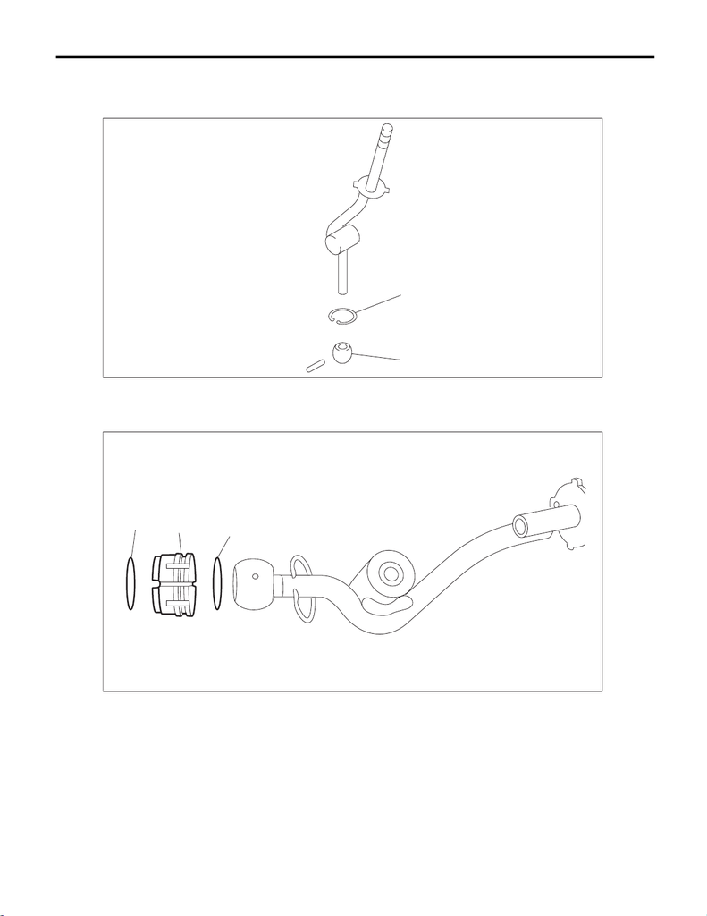

CS-74

MT Gear Shift Lever

CONTROL SYSTEMS

3) Install the snap ring and install the bushing.

NOTE:

Apply grease to the bushing.

4) Apply grease to the bushing and O-ring, and then install to gear shift lever.

(A) Bushing (B) Snap ring

(A) O-ring (B) Bushing

CS-01807

(A)

(B)

CS-01806

(A)

(B)

(A)

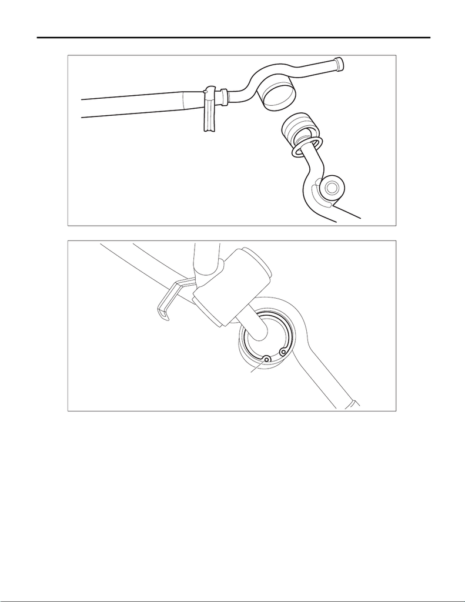

CS-75

MT Gear Shift Lever

CONTROL SYSTEMS

5) Apply sufficient grease into boss, and then install the gear shift lever to the stay.

6) Install the snap ring.

(A) Snap ring

CS-01805

CS-01804

(A)

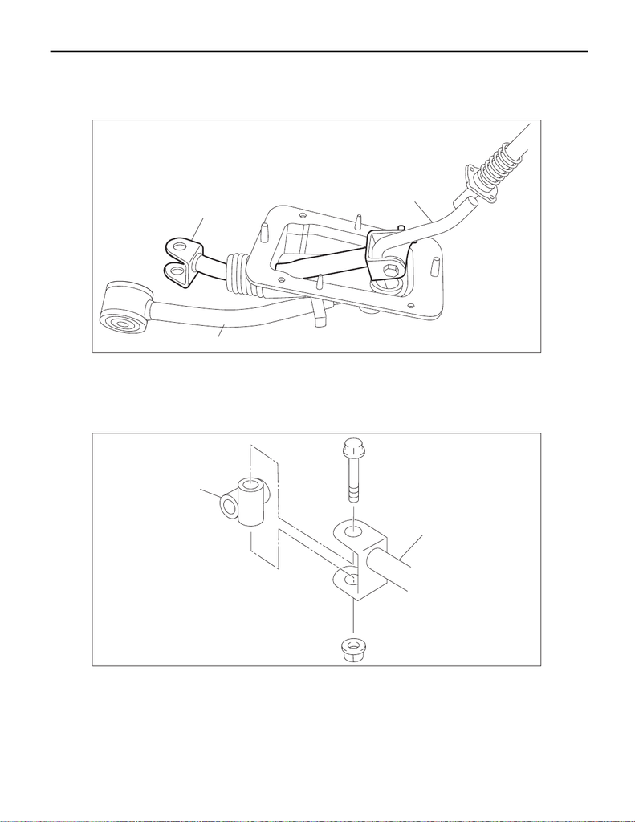

CS-76

MT Gear Shift Lever

CONTROL SYSTEMS

7) Insert the gear shift lever and rod into boot hole.

8) Install the rod.

Tightening torque:

12 N·m (1.2 kgf-m, 8.9 ft-lb)

9) Install the boss to the rod.

Tightening torque:

12 N·m (1.2 kgf-m, 8.9 ft-lb)

(A) Rod (B) Lever (C) Stay

(A) Rod (B) Boss

CS-01803

(C)

(A)

(B)

CS-01802

(B)

(A)

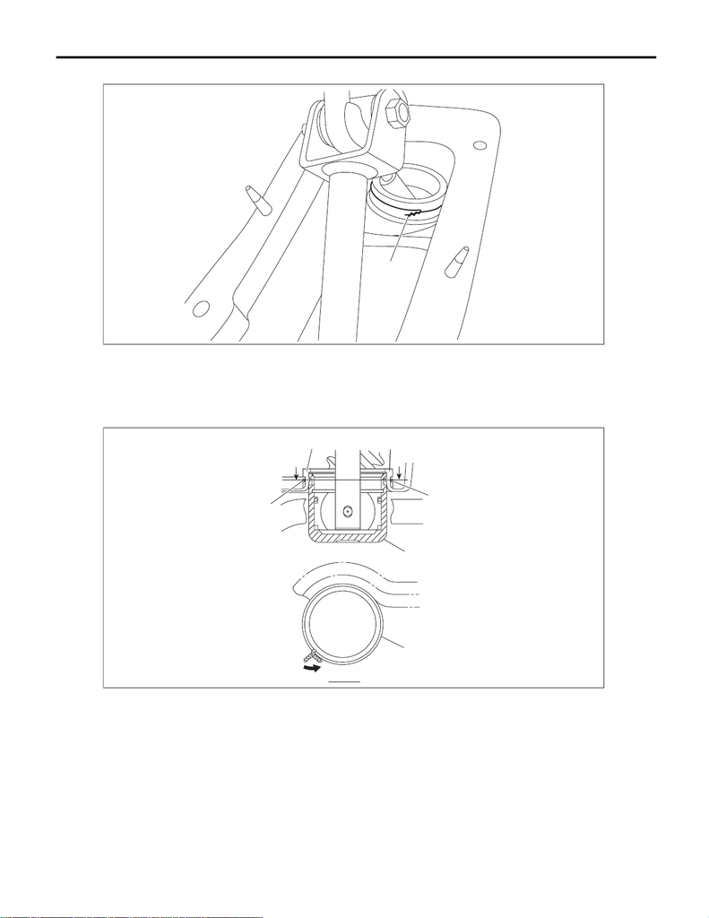

CS-77

MT Gear Shift Lever

CONTROL SYSTEMS

10) Install a new lock wire.

NOTE:

• Install the lock wire to the stay groove.

• Bend the extra wire to the same direction of lock wire winding.

(A) Lock wire

(A) Inner boot (B) Lock wire (C) Stay

CS-01801

(A)

CS-01810

(A)

(A)

(B)

(B)

B

B

(B)

B - B

(C)

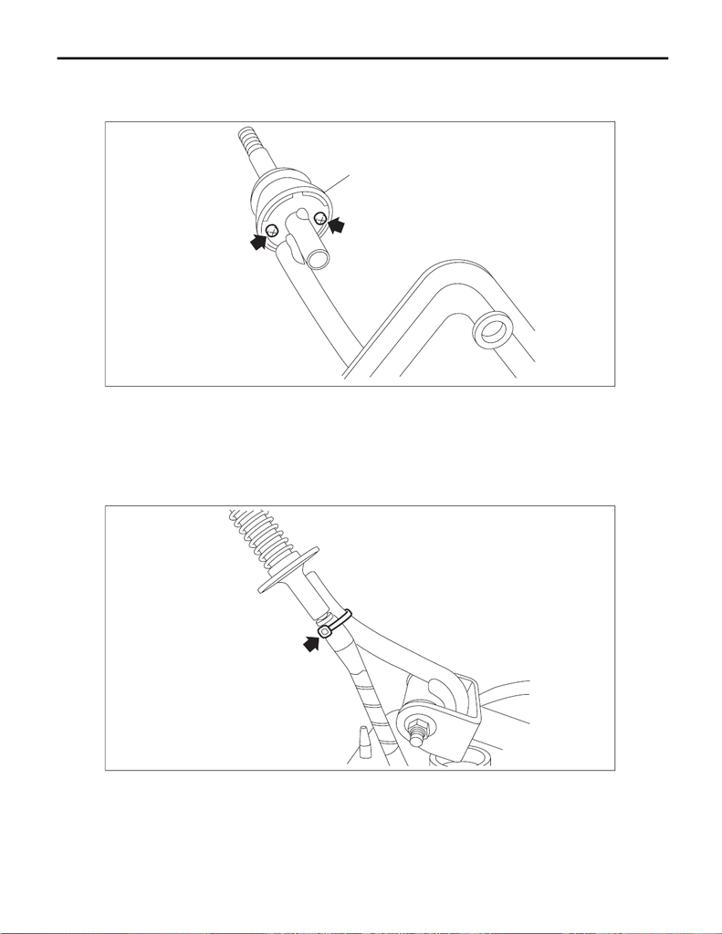

CS-78

MT Gear Shift Lever

CONTROL SYSTEMS

11) Install the holder.

Tightening torque:

1.3 N·m (0.1 kgf-m, 1.0 ft-lb)

12) Insert the reverse check cable into the boot hole.

13) Insert the reverse check cable into the gear shift assembly, and fix in place with a band clip.

NOTE:

• Cut the excess band clip.

• Make sure that the reverse check cable is inserted into the gearshift lever with no gaps.

(A) Holder

CS-01800

(A)

CS-01797

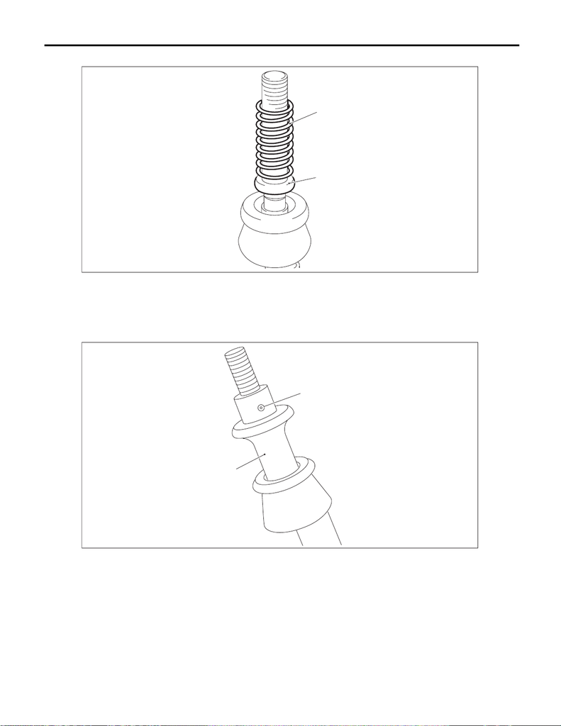

CS-79

MT Gear Shift Lever

CONTROL SYSTEMS

14) Install the seat cushion and spring.

15) Use the spring pin to secure the end of the slider and reverse check cable.

NOTE:

Apply grease to the moving part of slider.

(A) Spring (B) Seat cushion

(A) Slider (B) Spring pin

CS-01811

(A)

(B)

CS-01795

(A)

(B)

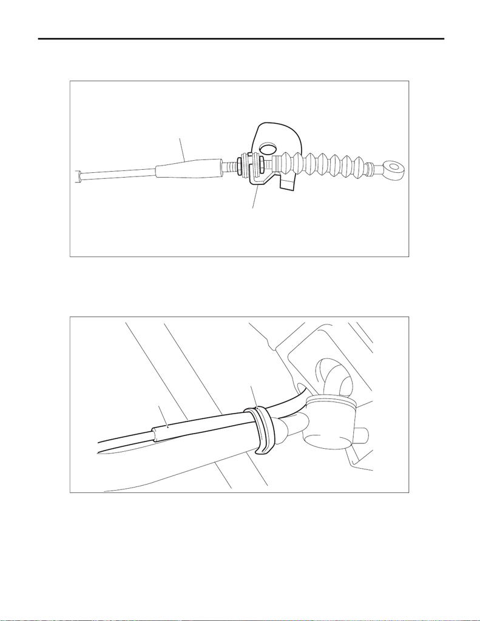

CS-80

MT Gear Shift Lever

CONTROL SYSTEMS

16) Install the reverse check cable to the cable plate, and tighten the lock nut.

Tightening torque:

6 N·m (0.6 kgf-m, 4.4 ft-lb)

17) Secure the reverse check cable to the stay clip.

NOTE:

Install the reverse check cable on top of the stay.

(A) Cable plate (B) Reverse check cable

(A) Reverse check cable (B) Clip

CS-01798

(A)

(B)

CS-01812

(A)

(B)

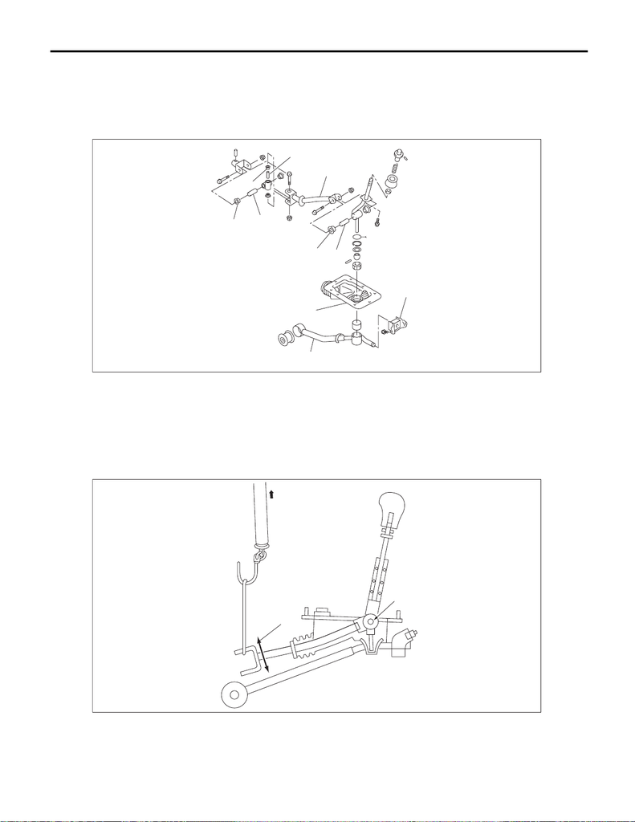

CS-81

MT Gear Shift Lever

CONTROL SYSTEMS

E: INSPECTION

1. STI MODEL

1) Check the parts (bushing, cushion rubber, spacer, boot, stay and rod, etc.) for deformation, damage and

wear. If necessary, correct or replace faulty parts. Compare the removed parts with new parts to judge if there

are damages or not.

2) Check the swing torque of rod linked with the gear shift lever.

If the torque exceeds the specifications, replace the bushing or retighten nuts.

Swing torque:

3.7 N (0.38 kgf, 0.83 lbf) or less

(A) Bushing (C) Spacer (E) Stay

(B) Cushion rubber (D) Boot (F) Rod

(A) Pivot (B) Swing torque

CS-01813

(F)

(B)

(A)

(A)

(C)

(C)

(C)

(A)

(D)

(E)

CS-01814

(A)

(B)

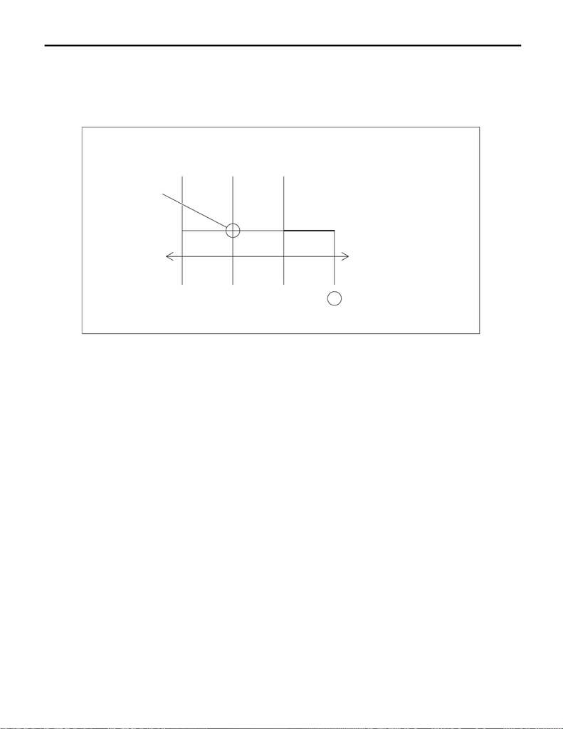

CS-82

MT Gear Shift Lever

CONTROL SYSTEMS

2. EXCEPT FOR STI MODEL

1) Check the parts for deformation, damage and wear. Repair or replace if necessary. Compare the removed

parts with new parts to confirm if there are damages or not.

2) Check that selecting to the reverse direction is disable unless the slider is pulled up.

3) Check that selecting to the reverse direction is possible when the slider is pulled up to the full.

4) Check that the shift lever moves to initial position, when the slider backs to “N” position from step 3).

F: ADJUSTMENT

NOTE:

Adjust the detent when the following items have been replaced. (Except for STI model)

• MT gear shift lever

• MT gear select cable

• Manual transmission assembly

1) Remove the console box assembly. <Ref. to EI-67, REMOVAL, Console Box.>

2) Remove the gear shift knob and remove the cover - shift lever. <Ref. to EI-67, REMOVAL, Console Box.>

3) Remove the panel center LWR LH and RH. <Ref. to EI-67, REMOVAL, Console Box.>

4) Install the gear shift knob.

5) Place the shift lever in neutral position.

1

2

3

4

5

6

CS-01177

R

N

SELECT DIRECTION

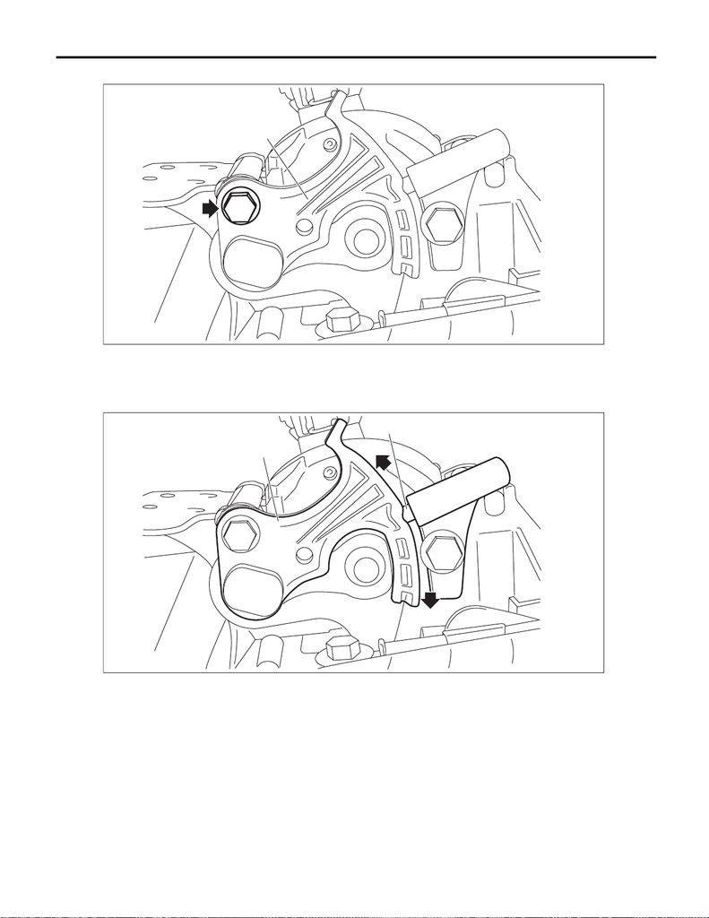

CS-83

MT Gear Shift Lever

CONTROL SYSTEMS

6) Loosen the detent bolt.

7) Move the detent up and down and align the detent pin to the groove. Make sure that the detent pin is fitted

in the groove and a clicking sound is heard.

(A) Detent

(A) Detent (B) Detent pin

(A)

CS-01583

(A)

(B)

CS-01584

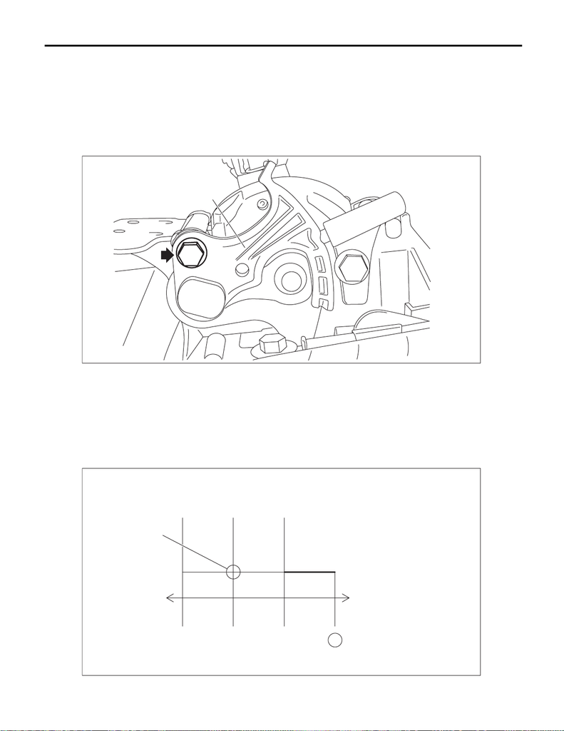

CS-84

MT Gear Shift Lever

CONTROL SYSTEMS

8) Pull up the slider, select the shift lever to the reverse direction, and make sure it returns to the neutral po-

sition after releasing hands.

9) Tighten the detent bolt.

NOTE:

When tightening the bolt, hold the shift lever by hand so that the detent pin does not come out from the

groove.

Tightening torque:

7.5 N·m (0.8 kgf-m, 5.5 ft-lb)

10) Move the shift lever to the neutral position, and check that the play in the select direction above the shift

knob is within the reference standard. If it is not within the reference standard, repeat adjustment procedures

from the beginning.

Play in neutral position:

Reference standard

1.5 mm (0.059 in) or less

(A) Detent

(A)

CS-01583

1

2

3

4

5

6

CS-01177

R

N

SELECT DIRECTION